# 10_uc_x_from_slope_Q1

## 10_uc_x_from_slope_Q1

#### Question

1. In the first quadrant, a point is on the [unit circle](https://en.wikipedia.org/wiki/Unit_circle) (centered at the origin). A line connecting the point to the origin has a slope of 0.38, as enforced by the diagram below:

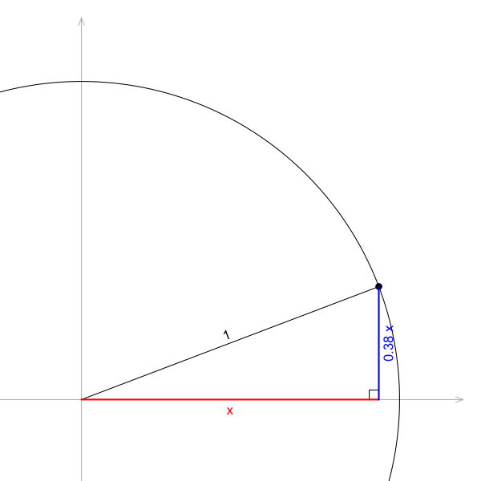

   Find a decimal approximation of $x$ accurate within $\pm 0.01$.

#### Question

2. In the first quadrant, a point is on the [unit circle](https://en.wikipedia.org/wiki/Unit_circle) (centered at the origin). A line connecting the point to the origin has a slope of 0.59, as enforced by the diagram below:

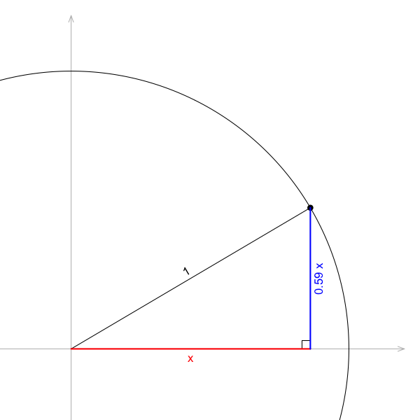

   Find a decimal approximation of $x$ accurate within $\pm 0.01$.

#### Question

3. In the first quadrant, a point is on the [unit circle](https://en.wikipedia.org/wiki/Unit_circle) (centered at the origin). A line connecting the point to the origin has a slope of 1.35, as enforced by the diagram below:

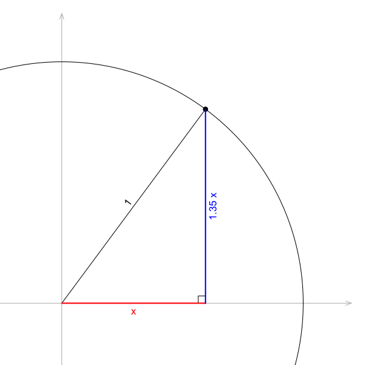

   Find a decimal approximation of $x$ accurate within $\pm 0.01$.

#### Question

4. In the first quadrant, a point is on the [unit circle](https://en.wikipedia.org/wiki/Unit_circle) (centered at the origin). A line connecting the point to the origin has a slope of 5.46, as enforced by the diagram below:

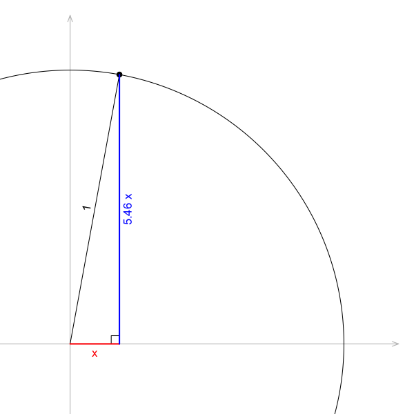

   Find a decimal approximation of $x$ accurate within $\pm 0.01$.

#### Question

5. In the first quadrant, a point is on the [unit circle](https://en.wikipedia.org/wiki/Unit_circle) (centered at the origin). A line connecting the point to the origin has a slope of 0.29, as enforced by the diagram below:

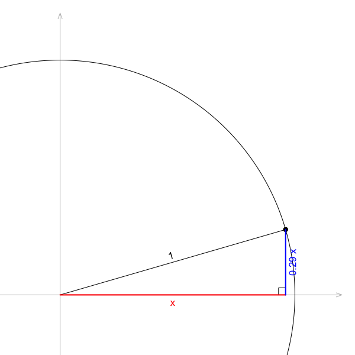

   Find a decimal approximation of $x$ accurate within $\pm 0.01$.

#### Question

6. In the first quadrant, a point is on the [unit circle](https://en.wikipedia.org/wiki/Unit_circle) (centered at the origin). A line connecting the point to the origin has a slope of 5.24, as enforced by the diagram below:

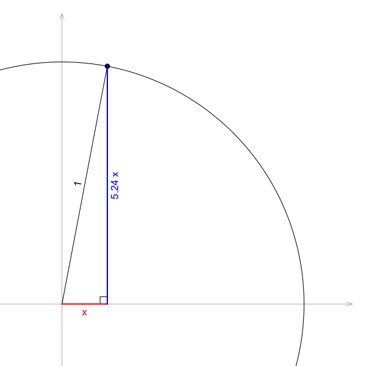

   Find a decimal approximation of $x$ accurate within $\pm 0.01$.

#### Question

7. In the first quadrant, a point is on the [unit circle](https://en.wikipedia.org/wiki/Unit_circle) (centered at the origin). A line connecting the point to the origin has a slope of 6.36, as enforced by the diagram below:

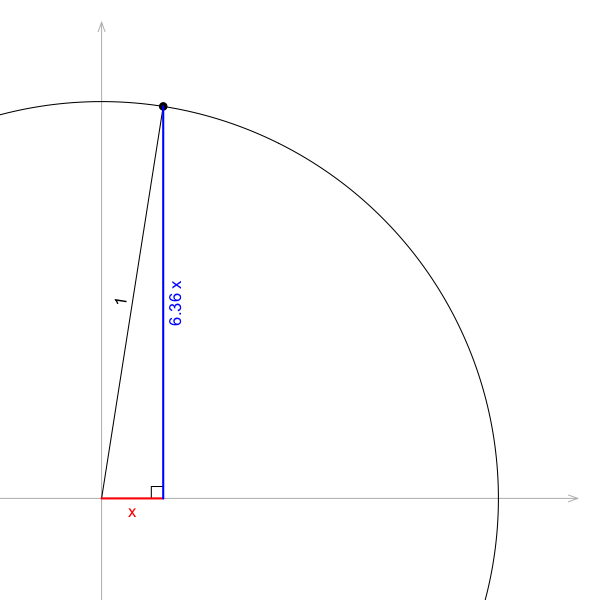

   Find a decimal approximation of $x$ accurate within $\pm 0.01$.

#### Question

8. In the first quadrant, a point is on the [unit circle](https://en.wikipedia.org/wiki/Unit_circle) (centered at the origin). A line connecting the point to the origin has a slope of 1.95, as enforced by the diagram below:

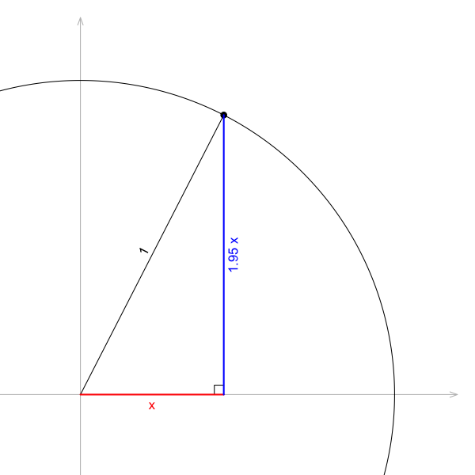

   Find a decimal approximation of $x$ accurate within $\pm 0.01$.